# Running the Individual Based Model

Timothée Bonnet

2024-10-28

This code is associated with the manuscript “Toward a unified approach to modeling adaptation among demographers and evolutionary ecologists” submitted to Methods in Ecology and Evolution (MEE) by Joanie Van de Walle, Jimmy Garnier, Timothée Bonnet and Stephanie Jenouvrier.

It demonstrates how we used the Individual Based Model (IBM) as implemented in the functions `IBM_Function.R` to generate the results presented in the manuscript.

Re-running all simulations might take up to a few days depending on how many cores are available. You can download a compressed file containing pre-run simulations at https://sdrive.cnrs.fr/s/yWYWNegiQWoAQfj.

# 1 Set-up

Load the packages needed to run the code:

```r
library(doParallel) # to run simulations multicore
library(popbio) # population matrix calculations
library(tidyverse) # data wrangling
```

Load all IBM simulation and post-treatment functions:

```r
source("IBM_Function.R")
```

# 2 Define species

We define 5 species as a collection of vital rates and life-history properties.

```r
species_info <- data.frame(species=1:5,
                           fecundity = c(10.9868, 4.9958, 0.9987 ,0.3004 , 0.2286),
                           fertility = c(10.9868/0.0965, 4.9958/0.25, 0.9987/0.385 ,0.3004/0.505 , 0.2286/0.8),
                           adult_survival = c(0.0365, 0.2, 0.8, 0.93, 0.95),
                           juvenile_survival = c(0.0965, 0.25, 0.385, 0.505, 0.8),
                           maturation_rate = c(0.9, 0.572, 0.4, 0.3, 0.07),
                           generation_time = c(2.0476, 2.3697, 6.2983, 15.8066, 23.7847))
```

We compute the expected asymptotic growth rate and stage structure at the begining of the simulation (they may change through time because of selection and genetic change).

```r
species_info$lambda <- NA
species_info$juv_prop <- NA

for (i in 1:nrow(species_info))
{
  leslie_pop <- matrix(c(species_info$juvenile_survival[i] * ( 1 - species_info$maturation_rate[i]),
         species_info$fecundity[i],
         species_info$juvenile_survival[i] * species_info$maturation_rate[i],
         species_info$adult_survival[i]),
       nrow = 2, byrow = TRUE)


  species_info$lambda[i] <- lambda(leslie_pop)
  species_info$juv_prop[i] <- stable.stage(leslie_pop)[1]
}

write_csv(species_info, file = "species_info.csv")
```

# 3 Run the IBM across species and vital rates

We run the IBM one vital rate at the time, looping over the species.

In order to speed up computation we use parallel computing for the inner for-loop. Assuming you have 4 independent cores available to run the IBM, you can start the virtual cluster with:

```r
cl <- makeCluster(4)
registerDoParallel(cl)
```

If you have more cores available, for instance 20 you would use:

```r
cl <- makeCluster(20)
registerDoParallel(cl)
```

After running one of the for-loops below you should close the virtual cluster with:

```r
stopCluster(cl)
```

This will shut down the background R-sessions.

If you do not want to use parallel computing, you should replace `foreach (j = 1:100) %dopar%` with `for (j in 1:100)`.

## 3.1 Juvenile survival selection

We will comment the code in the case of selection on juvenile survival; the code for selection on other vital rates is almost identical except for the beta parameters and the name of the objects to which we save simulation outputs. By default, the different beta are set to zero (`beta_s_j=0, beta_s_a=0, beta_f=0, beta_m=0`), meaning there is no selection. You can tell which vital rate is under selection based on which “beta” is non-zero, here `beta_s_j <- 0.15` means selection is on juvenile survival.

In case it is not already done, we load the IBM functions and the species vital rates:

```r
source("IBM_Function.R")
species_info <- read.csv("species_info.csv")
```

We define some input parameters:

```r
VP <- 1 # phenotypic variance in the trait under selection
heritability <- 0.2 # heritability
beta_s_j <- 0.15 # selection slope on the linear scale of the vital rate (log or logit)
init_pop_size <- 2*100 # initial population size. The factor 2 accounts for males (not important)
nb_years <- 100 # number of time steps for which to run the simulation
K <- 2000 # safeguard carrying capacity to prevent very long simulations
```

We now loop over the five species, first extracting the species-specific vital rates, and then running the IBM 100 times (`foreach (j = 1:100) %dopar%` commands the parallel loop).

The function `main_simul()` does all the computing. We then save the output to a folder `simulations` that is created in the first line of the code chunk if it does not already exist.

Note that we do not re-run the simulation if the output already exists in the folder. This allows to potentially start and stop the computation without re-doing all replicates.

```r
if( !dir.exists("simulations") ) dir.create("simulations") )

for (i in 1:nrow(species_info))
{
  survival_j <- species_info$juvenile_survival[i]
  survival_a <- species_info$adult_survival[i]
  maturation <- species_info$maturation_rate[i]
  fecundity <- species_info$fertility[i]*2 # multiply by 2 to account for males # in the case of Juv survival we need to use Fertility instead of Fecundity
  init_prop_juv <- species_info$juv_prop[i]

  foreach (j = 1:100) %dopar%
  {
    if(! paste0("pop_sel_species_s_j_",i, "_rep_",j) %in% list.files("simulations") )
      {
      pop_sel <- main_simul(init_pop_size=init_pop_size,
                         start = 1, end = nb_years,
                         fecundity = fecundity, VP = VP, VA = heritability*VP,
                         maturation_rate = maturation,
                         surv_j = survival_j, surv_a = survival_a, beta_s_j = beta_s_j, init_prop_juv=init_prop_juv,
                         K=K)
      save(pop_sel, file = paste0("simulations/pop_sel_species_s_j_",i, "_rep_",j))
    }
  print(j)
  }
}
```

### 3.1.1 Post-hoc treatment of simulations

The IBM outputs contains tables of individual life-histories. For convenience, we post-process them to produce more different secondary outputs.

First, we compute the population size for every year in each simulation, then we combine the different replicates together. This is quite slow (and could probably be optimized a lot).

```r
for (i in 1:nrow(species_info))
{
  foreach (j = 1:100) %dopar%
  {
    if(paste0("pop_sel_species_s_j_",i, "_rep_",j) %in% list.files("simulations") )
      if(!paste0("pop_data_species_s_j_",i, "_rep_",j, ".csv") %in% list.files("simulations") )
      {
        load(paste0("simulations/pop_sel_species_s_j_",i, "_rep_",j))
        pop_data <- produce_pop_data(pop_sel)
        write_csv(pop_data, file = paste0("simulations/pop_data_species_s_j_",i, "_rep_",j, ".csv"))
      }
    print(j)
  }
}

pop_data_all_s_j <- tibble()
for (i in 1:nrow(species_info))
{
  for (j in 1:100)
  {
    pop_data <- read.csv(paste0("simulations/pop_data_species_s_j_",i, "_rep_",j, ".csv"))
    pop_data$species <- i
    pop_data$replicate <- j
    pop_data_all_s_j <- bind_rows(pop_data_all_s_j, pop_data)
  }
}
write.csv(pop_data_all_s_j, "simulations/pop_data_all_s_j.csv")
```

Here, we compute breeding value average per cohort for each simulation replicates, and then combine the simulation replicates together: Here we tested two ways of averaging breeding values, either by cohort (`produce_evolution_data()`), or by year (`produce_evolution_data_byyear()`).

```r
all_pop_s_j <- tibble()
for (i in 1:nrow(species_info))
{
  for (j in 1:100)
  {
    if(paste0("pop_sel_species_s_j_",i, "_rep_",j) %in% list.files("simulations") )
      {
        load(paste0("simulations/pop_sel_species_s_j_",i, "_rep_",j))
        pop_evol <- produce_evolution_data(pop_sel, minyear = 1)
        pop_evol$species <- i
        pop_evol$replicate <- j
        all_pop_s_j <- bind_rows(all_pop_s_j, pop_evol)
      }
  }
}
write.csv(all_pop_s_j, file = "simulations/pop_evol_s_j.csv")

# by year evolution
all_pop_by_s_j <- tibble()
for (i in 1:nrow(species_info))
{
  for (j in 1:100)
  {
    if(paste0("pop_sel_species_s_j_",i, "_rep_",j) %in% list.files("simulations") )
      {
        load(paste0("simulations/pop_sel_species_s_j_",i, "_rep_",j))
        pop_evol <- produce_evolution_data_byyear(pop_sel, minyear = 1)
        pop_evol$species <- i
        pop_evol$replicate <- j
        all_pop_by_s_j <- bind_rows(all_pop_by_s_j, pop_evol)
    }
  }
}

write.csv(all_pop_by_s_j, file = "simulations/pop_evol_by_s_j.csv")
```

### 3.1.2 A quick look at the post-processed outputs

```r
library(tidyverse) # for wrangling and plotting
all_pop_s_j <- read_csv("../Code_QGMPM_MEE/simulations/pop_evol_s_j.csv")
```

```
## ──────────────────────────────────────────────────────── Delimiter: "," dbl
## (6): ...1, birthyear, mean_pheno, mean_bv, species, replicate
```

We can visualise the change in mean breeding values through birth years for each of the 100 replicates in each species:

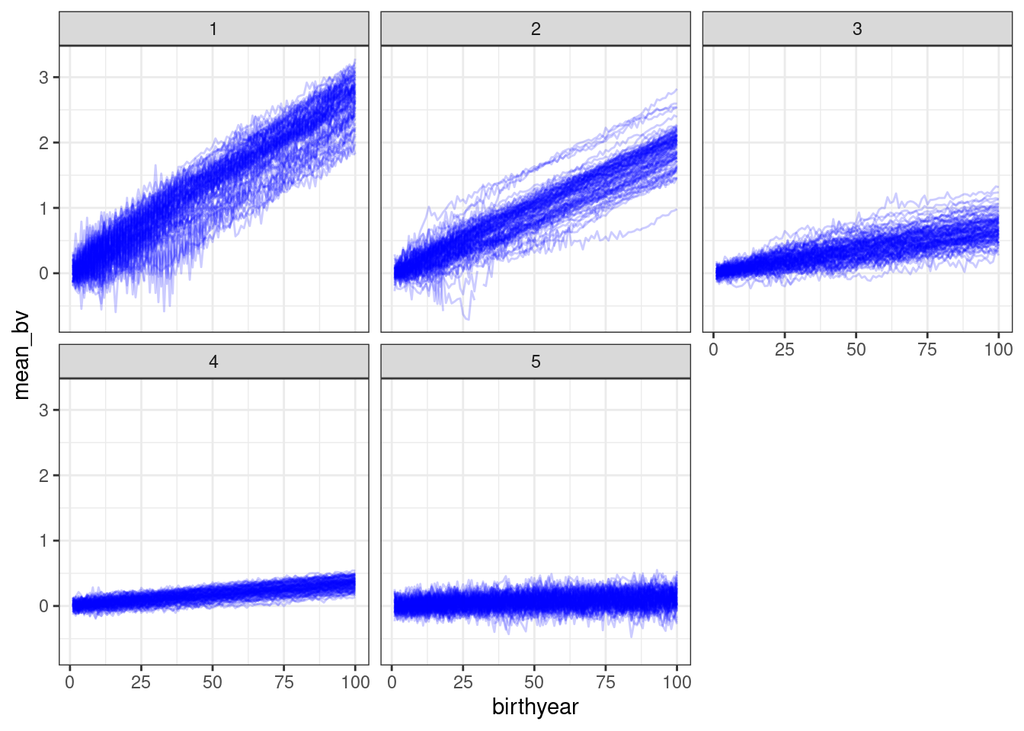

```r
ggplot(all_pop_s_j, aes(x=birthyear, y=mean_bv, by=as.factor(replicate))) +
  geom_line(alpha=0.2, color="blue") +
  facet_wrap(~species) +
  theme_bw() +
  theme(legend.position = "none")
```

## 3.2 Adult survival selection

```r
source("IBM_Function.R")

library(tidyverse)
species_info <- read.csv("species_info.csv")

VP <- 1
heritability <- 0.2
beta_s_a <- 0.15
init_pop_size <- 2*100 # multiply by 2 to account for males
nb_years <- 100

K <- 5000 #safeguard to prevent very long simulations

for (i in 1:nrow(species_info))
{
  survival_j <- species_info$juvenile_survival[i]
  survival_a <- species_info$adult_survival[i]
  maturation <- species_info$maturation_rate[i]
  fecundity <- species_info$fecundity[i]*2 # multiply by 2 to account for males
  init_prop_juv <- species_info$juv_prop[i]

  for (j in 1:100)
  {
    if(! paste0("pop_sel_species_sa_",i, "_rep_",j) %in% list.files("simulations") )
      {
      pop_sel <- main_simul(init_pop_size=init_pop_size,
                         start = 1, end = nb_years,
                         fecundity = fecundity, VP = VP, VA = heritability*VP,
                         maturation_rate = maturation,
                         surv_j = survival_j, surv_a = survival_a, beta_s_a=beta_s_a,
                         init_prop_juv=init_prop_juv,
                         K=K)
      save(pop_sel, file = paste0("simulations/pop_sel_species_sa_",i, "_rep_",j))
    }
  print(j)
  }
}
```

```r
for (i in 1:nrow(species_info))
{
  for (j in 1:100)
  {
    if(paste0("pop_sel_species_sa_",i, "_rep_",j) %in% list.files("simulations") )
      if(!paste0("pop_data_species_sa_",i, "_rep_",j, ".csv") %in% list.files("simulations") )
      {
        load(paste0("simulations/pop_sel_species_sa_",i, "_rep_",j))
        pop_data <- produce_pop_data(pop_sel)
        write_csv(pop_data, file = paste0("simulations/pop_data_species_sa_",i, "_rep_",j, ".csv"))
      }
    print(j)
  }
}

pop_data_all_s_a <- tibble()

for (i in 1:nrow(species_info))
{
  for (j in 1:100)
  {
    pop_data <- read.csv(paste0("simulations/pop_data_species_sa_",i, "_rep_",j, ".csv"))
    pop_data$species <- i
    pop_data$replicate <- j
    pop_data_all_s_a <- bind_rows(pop_data_all_s_a, pop_data)
  }
}

write.csv(pop_data_all_s_a, "simulations/pop_data_all_s_a.csv")
```

```r
all_pop_s_a <- tibble()
for (i in 1:nrow(species_info))
{
  for (j in 1:100)
  {
    if(paste0("pop_sel_species_sa_",i, "_rep_",j) %in% list.files("simulations") )
      {
        load(paste0("simulations/pop_sel_species_sa_",i, "_rep_",j))
        pop_evol <- produce_evolution_data(pop_sel, minyear = 1)
        pop_evol$species <- i
        pop_evol$replicate <- j
        all_pop_s_a <- bind_rows(all_pop_s_a, pop_evol)
    }
  }
}

write.csv(all_pop_s_a, file = "simulations/pop_evol_s_a.csv")

#by year evolution
all_pop_by_s_a <- tibble()
for (i in 1:nrow(species_info))
{
  for (j in 1:100)
  {
    if(paste0("pop_sel_species_sa_",i, "_rep_",j) %in% list.files("simulations") )
      {
        load(paste0("simulations/pop_sel_species_sa_",i, "_rep_",j))
        pop_evol <- produce_evolution_data_byyear(pop_sel, minyear = 1)
        pop_evol$species <- i
        pop_evol$replicate <- j
        all_pop_by_s_a <- bind_rows(all_pop_by_s_a, pop_evol)
    }
  }
}

write.csv(all_pop_by_s_a, file = "simulations/pop_evol_by_s_a.csv")
```

## 3.3 Fertility selection

```r
source("IBM_Function.R")

library(tidyverse)
species_info <- read.csv("species_info.csv")

VP <- 1
heritability <- 0.2
beta_f <- 0.15*2
init_pop_size <- 2*100 # multiply by 2 to account for males
nb_years <- 100

K <- 5000 #safeguard to prevent very long simulations

for (i in 1:nrow(species_info))
{
  survival_j <- species_info$juvenile_survival[i]
  survival_a <- species_info$adult_survival[i]
  maturation <- species_info$maturation_rate[i]
  fecundity <- species_info$fecundity[i]*2 # multiply by 2 to account for males
  init_prop_juv <- species_info$juv_prop[i]

  for (j in 1:100)
  {
    if(! paste0("pop_sel_species_f_",i, "_rep_",j) %in% list.files("simulations") )
      {
      pop_sel <- main_simul(init_pop_size=init_pop_size,
                         start = 1, end = nb_years,
                         fecundity = fecundity, VP = VP, VA = heritability*VP,
                         maturation_rate = maturation,
                         surv_j = survival_j, surv_a = survival_a, beta_f=beta_f,
                         init_prop_juv=init_prop_juv,
                         K=K, repro_model="poisson")
      save(pop_sel, file = paste0("simulations/pop_sel_species_f_",i, "_rep_",j))
    }
  print(j)
  }
}
```

```r
for (i in 1:nrow(species_info))
{
  for (j in 1:100)
  {
    if(paste0("pop_sel_species_f_",i, "_rep_",j) %in% list.files("simulations") )
      if(!paste0("pop_data_species_f_",i, "_rep_",j, ".csv") %in% list.files("simulations") )
      {
        load(paste0("simulations/pop_sel_species_f_",i, "_rep_",j))
        pop_data <- produce_pop_data(pop_sel)
        write_csv(pop_data, file = paste0("simulations/pop_data_species_f_",i, "_rep_",j, ".csv"))
      }
    print(j)
  }
}

pop_data_all_f <- tibble()
for (i in 1:nrow(species_info))
{
  for (j in 1:100)
  {
    pop_data <- read.csv(paste0("simulations/pop_data_species_f_",i, "_rep_",j, ".csv"))
    pop_data$species <- i
    pop_data$replicate <- j
    pop_data_all_f <- bind_rows(pop_data_all_f, pop_data)
  }
}
write.csv(pop_data_all_f, "simulations/pop_data_all_f.csv")

all_pop_f <- tibble()
for (i in 1:nrow(species_info))
{
  for (j in 1:100)
  {
    if(paste0("pop_sel_species_f_",i, "_rep_",j) %in% list.files("simulations") )
      {
        load(paste0("simulations/pop_sel_species_f_",i, "_rep_",j))
        pop_evol <- produce_evolution_data(pop_sel, minyear = 1)
        pop_evol$species <- i
        pop_evol$replicate <- j
        all_pop_f <- bind_rows(all_pop_f, pop_evol)
      }
  }
}
write.csv(all_pop_f, file = "simulations/pop_evol_f.csv")

#by year calculation instead of by cohort
all_pop_f_by <- tibble()
for (i in 1:nrow(species_info))
{
  for (j in 1:100)
  {
    if(paste0("pop_sel_species_f_",i, "_rep_",j) %in% list.files("simulations") )
      {
        load(paste0("simulations/pop_sel_species_f_",i, "_rep_",j))
        pop_evol_by <- produce_evolution_data_byyear(pop_sel, minyear = 1)
        pop_evol_by$species <- i
        pop_evol_by$replicate <- j
        all_pop_f_by <- bind_rows(all_pop_f_by, pop_evol_by)
    }
  }
}

write.csv(all_pop_by_f, file = "simulations/pop_evol_by_f.csv")
```

## 3.4 Maturity selection

```r
source("IBM_Function.R")

library(tidyverse)
species_info <- read.csv("species_info.csv")

VP <- 1
heritability <- 0.2
beta_m <- 0.15
init_pop_size <- 2*100 # multiply by 2 to account for males
nb_years <- 100

K <- 5000 #safeguard to prevent very long simulations

for (i in 1:nrow(species_info))
{
  survival_j <- species_info$juvenile_survival[i]
  survival_a <- species_info$adult_survival[i]
  maturation <- species_info$maturation_rate[i]
  fecundity <- species_info$fecundity[i]*2 # multiply by 2 to account for males
  init_prop_juv <- species_info$juv_prop[i]

  for (j in 1:100)
  {
    if(! paste0("pop_sel_species_m_",i, "_rep_",j) %in% list.files("simulations") )
      {
      pop_sel <- main_simul(init_pop_size=init_pop_size,
                         start = 1, end = nb_years,
                         fecundity = fecundity, VP = VP, VA = heritability*VP,
                         maturation_rate = maturation,
                         surv_j = survival_j, surv_a = survival_a, beta_m=beta_m,
                         init_prop_juv=init_prop_juv,
                         K=K)
      save(pop_sel, file = paste0("simulations/pop_sel_species_m_",i, "_rep_",j))
    }
  print(j)
  }
}
```

```r
for (i in 1:nrow(species_info))
{
  for (j in 1:100)
  {
    if(paste0("pop_sel_species_m_",i, "_rep_",j) %in% list.files("simulations") )
      if(!paste0("pop_data_species_m_",i, "_rep_",j, ".csv") %in% list.files("simulations") )
      {
        load(paste0("simulations/pop_sel_species_m_",i, "_rep_",j))
        pop_data <- produce_pop_data(pop_sel)
        write_csv(pop_data, file = paste0("simulations/pop_data_species_m_",i, "_rep_",j, ".csv"))
      }
    print(j)
  }
}

pop_data_all_m <- tibble()

for (i in 1:nrow(species_info))
{
  for (j in 1:100)
  {
    pop_data <- read.csv(paste0("simulations/pop_data_species_m_",i, "_rep_",j, ".csv"))
    pop_data$species <- i
    pop_data$replicate <- j
    pop_data_all_m <- bind_rows(pop_data_all_m, pop_data)
  }
}

write.csv(pop_data_all_m, "simulations/pop_data_all_m.csv")
```

```r
all_pop_m <- tibble()
for (i in 1:nrow(species_info))
{
  for (j in 1:100)
  {
    if(paste0("pop_sel_species_m_",i, "_rep_",j) %in% list.files("simulations") )
      {
        load(paste0("simulations/pop_sel_species_m_",i, "_rep_",j))
        pop_evol <- produce_evolution_data(pop_sel, minyear = 1)
        pop_evol$species <- i
        pop_evol$replicate <- j
        all_pop_m <- bind_rows(all_pop_m, pop_evol)
    }
  }
}

write.csv(all_pop_m, file = "simulations/pop_evol_m.csv")

#by year calculation instead of by cohort
all_pop_by_m <- tibble()
for (i in 1:nrow(species_info))
{
  for (j in 1:100)
  {
    if(paste0("pop_sel_species_m_",i, "_rep_",j) %in% list.files("simulations") )
      {
        load(paste0("simulations/pop_sel_species_m_",i, "_rep_",j))
        pop_evol <- produce_evolution_data_byyear(pop_sel, minyear = 1)
        pop_evol$species <- i
        pop_evol$replicate <- j
        all_pop_by_m <- bind_rows(all_pop_by_m, pop_evol)
    }
  }
}

write.csv(all_pop_by_m, file = "simulations/pop_evol_by_m.csv")
```